# Exercise Solutions: Section 4.10

Rob J Hyndman & George Athanasopoulos

## Exercise 4.1

```r
require(fpp) # fpp package needs to be loaded once in the beginning of every R session
econsumption
```

```
    Mwh temp
1  16.3 29.3
2  16.8 21.7
3  15.5 23.7
4  18.2 10.4
5  15.2 29.7
6  17.5 11.9
7  19.8  9.0
8  19.0 23.4
9  17.5 17.8
10 16.0 30.0
11 19.6  8.6
12 18.0 11.8
```

Plotting the data and finding the regression model:

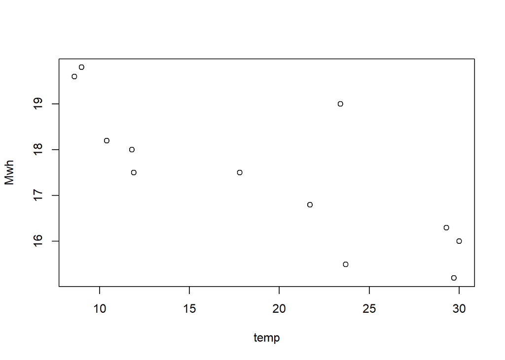

```r
plot(Mwh ~ temp, data = econsumption)
```

```r
(fit = lm(Mwh ~ temp, data = econsumption))
```

```
Call:
lm(formula = Mwh ~ temp, data = econsumption)

Coefficients:
(Intercept)         temp
    20.1995      -0.1452
```

```r
# brackets outside the expression are for printing the result
```

There is a negative relationship between temperature and electricity consumption.

Probably for the temperature range involved and during the time when the data were observed, a lot of electricity was used for heating. Since low temperatures induced higher demand for heating, it led to a negative relationship between temperature and electricity consumption.

In addition, lower temperatures encouraged people to stay inside houses, where they naturally consumed more electricity compare to when they were outside their houses.

Residual plot

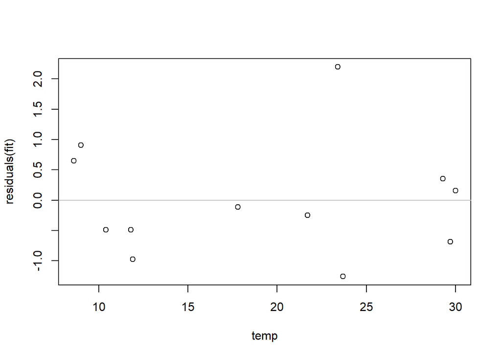

```r
plot(residuals(fit) ~ temp, data = econsumption)
abline(0, 0, col="grey")
```

```r
# Horizontal line with zero intercept is useful for assesment of the residuals
```

The residuals do not show obvious patterns or heteroscedasticity (i.e. when the residuals show non-constant variance). Therefore the model can be considered as adequate. Although small number of observations do not allow to be conclusive.

There is at least one outlier. It is observation number 8: consumption 19.0 Mwh and temperature 23.4$^\circ$.

There are no obvious influential observations, although the outlier can be considered as a good candidate for one of them.

Prediction of the electricity consumption for a day with maximum temperature 10$^\circ$ and a day with maximum temperature 35$^\circ$.

```r
forecast(fit, newdata=data.frame(temp=c(10,35)))
```

```
  Point Forecast    Lo 80    Hi 80    Lo 95    Hi 95
1       18.74795 17.27010 20.22579 16.34824 21.14766
2       15.11902 13.50469 16.73335 12.49768 17.74035
```

Plot of the training set and the forecast:

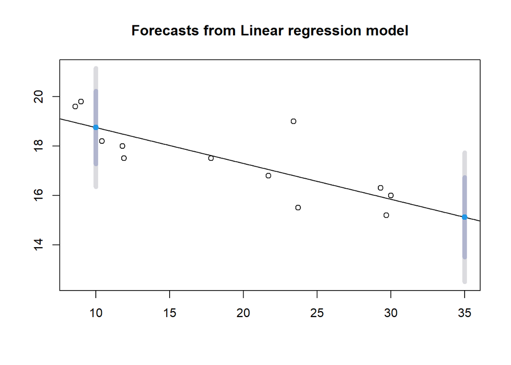

```r
plot(forecast(fit, newdata=data.frame(temp=c(10,35))))
```

The forecast is more believable for temperature 10$^\circ$ rather than for temperature 35$^\circ$ because the second value lies outside the region of observed temperatures in the training set.

## Exercise 4.2

The original data set

```r
olympic
```

```
   Year  time
1  1896 54.20
2  1900 49.40
3  1904 49.20
4  1908 50.00
5  1912 48.20
6  1920 49.60
7  1924 47.60
8  1928 47.80
9  1932 46.20
10 1936 46.50
11 1948 46.20
12 1952 45.90
13 1956 46.70
14 1960 44.90
15 1964 45.10
16 1968 43.80
17 1972 44.66
18 1976 44.26
19 1980 44.60
20 1984 44.27
21 1988 43.87
22 1992 43.50
23 1996 43.49
```

To update dataset with the winning times from the last few Olympics, data is taken from and \url{http://en.wikipedia.org/wiki/Athletics_at_the_2012_Summer_Olympics_%E2%80%93_Men%27s_400_metres}.

```r
olympic = rbind(olympic, data.frame(Year = c(2000, 2004, 2008, 2012),
                                    time = c(43.84, 44.00, 43.75, 43.94)))
tail(olympic)
```

```
   Year  time
22 1992 43.50
23 1996 43.49
24 2000 43.84
25 2004 44.00
26 2008 43.75
27 2012 43.94
```

Plot of the updated dataset with the winning times from the last few Olympics:

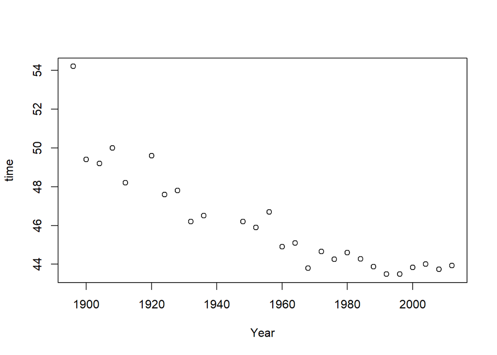

```r
plot(time ~ Year, data = olympic)
```

Plot of the data with the fitted regression line to the data:

```r
(fit = lm(time ~ Year, data = olympic))
```

```
Call:
lm(formula = time ~ Year, data = olympic)

Coefficients:
(Intercept)         Year
  174.95440     -0.06585
```

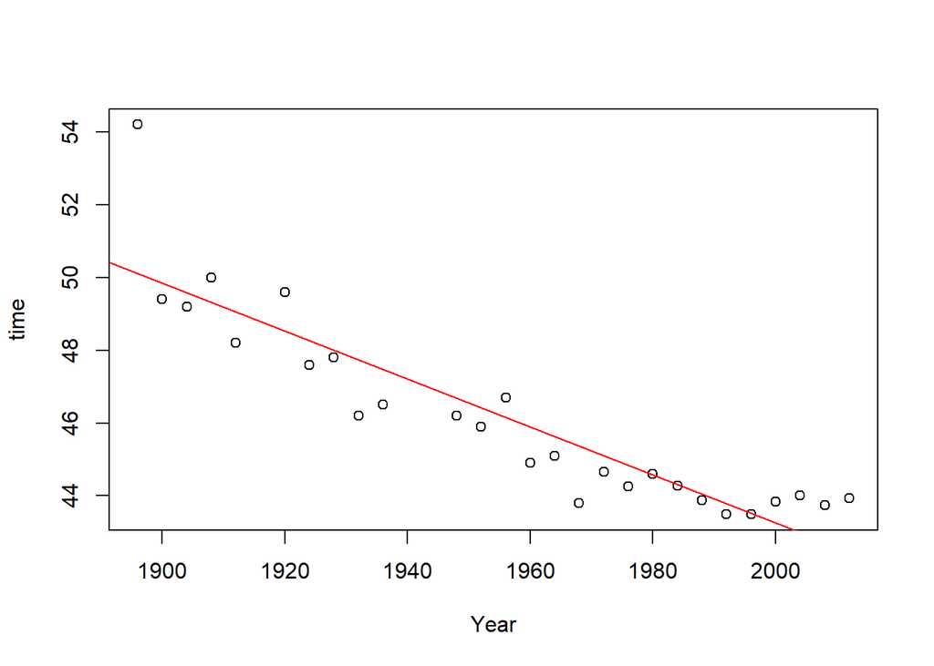

```r
plot(time ~ Year, data = olympic)
abline(a = fit$coefficients[1], b = fit$coefficients[2], col = "red")
```

The winning times have been decreasing with *average* rate of 0.066 second per year.

Plot of the residuals against the year:

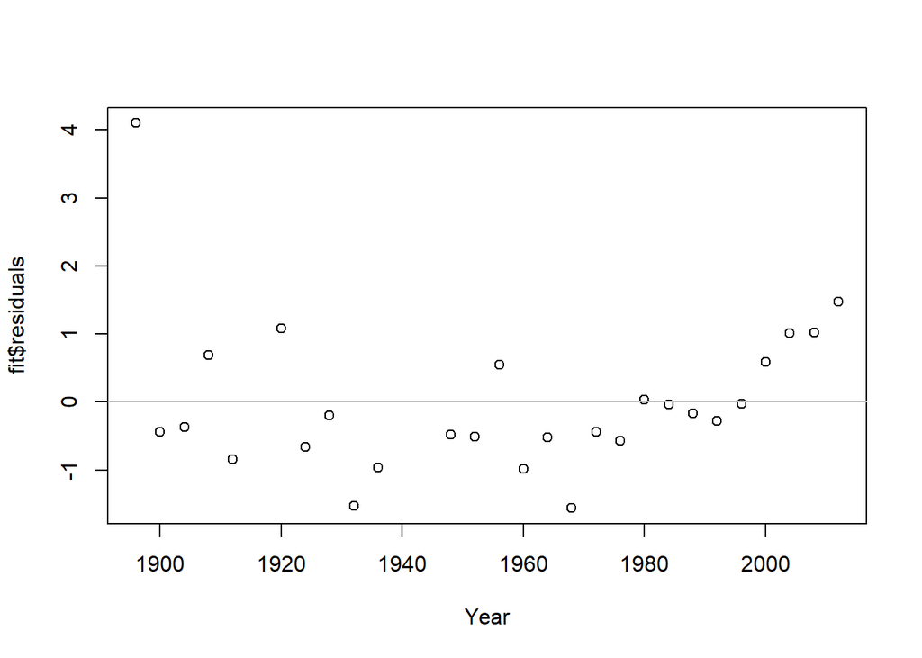

```r
plot(fit$residuals ~ Year, data = olympic)
abline(h = 0, col = "grey")
```

Prediction of the winning times for the men’s 400 meters final in the 2000, 2004, 2008 and 2012 Olympics:

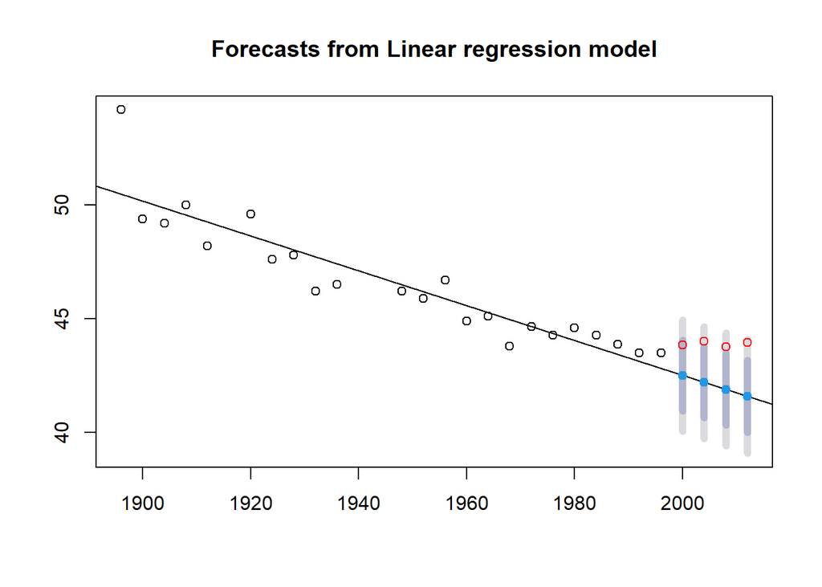

```r
trainingSet = olympic[1:23,]
testSet = olympic[24:27,]
fitOverTheTrainingSet = lm(time ~ Year, data = trainingSet)
plot(forecast(fitOverTheTrainingSet, newdata = testSet[,"Year"]))
lines(time ~ Year, data = testSet, col = "red", type = "p")
```

The above calculations are made with the assumption that the the men’s 400 meters Olympics final results change on average with constant rate. The forecasts are not very good although the real results are inside 95% prediction intervals.

## Exercise 4.3

The log-log model is written as: $\log(y) = \beta_0 + \beta_1 \log(x) + \varepsilon$.

We will take conditional expectation of the left and the right parts of the equation:

$\mathrm{E}(\log(y)\mid x) = \mathrm{E}(\beta_0 + \beta_1 \log(x) + \varepsilon\mid x) = \beta_0 + \beta_1\log(x)$.

By taking derivatives of the left and the right parts of the last equation we get:

$\frac{y'}{y} = \frac{\beta_1}{x}$, and then $\beta_1 = \frac{y' x}{y}$.

It is exactly what we need to prove, taking into account that $y' = \frac{dy}{dx}$.